# Model Performance Report — Pre-Production Defect Risk Scorer

Section 1

## Executive Summary

270

Jobs Scored

40

High Risk Flags

14.8% of jobs · 95.0% precision

Section 2

## Scoring Summary

Work Orders by Risk Tier

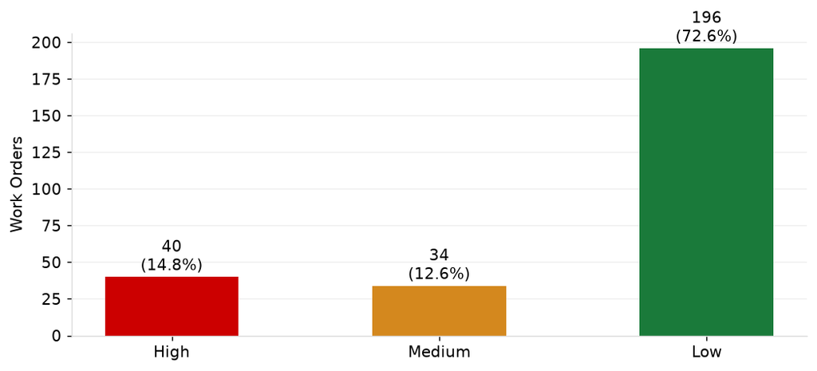

Jobs are scored before production runs. High and Medium tier jobs are flagged for pre-production review.

Distribution of Predicted Defect Probabilities

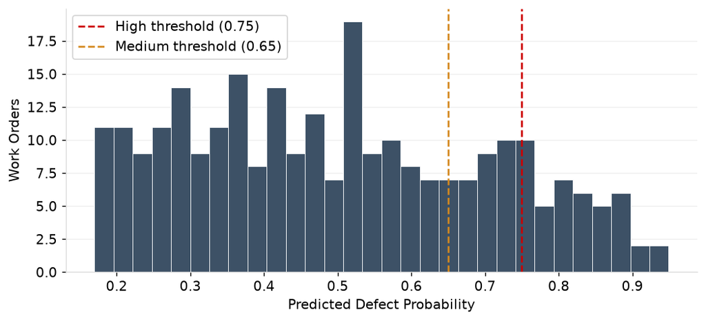

Vertical lines mark the High and Medium risk thresholds. Jobs to the right of each line are flagged at that tier.

Weekly Risk Tier Distribution

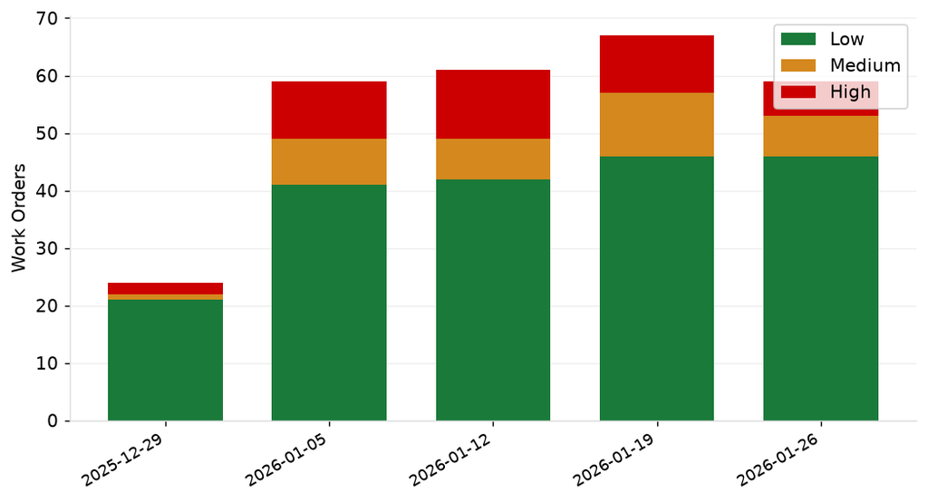

Flagged job volume across the scoring period. Stable distribution indicates consistent model operation.

Section 3

## Top Risk Drivers

Top Risk Drivers

[output not shown]

Top High-Risk Flagged Jobs Detail

[output not shown]

Section 4

## Accuracy Retrospective

Because this scoring period covers historical data with known outcomes, we can evaluate how accurately the model's flags mapped to actual defect events. Precision measures what fraction of flags were correct; recall measures what fraction of all defective jobs were successfully flagged.

| Risk Tier | Threshold | Jobs Flagged | True Positives | False Positives | Precision | Recall |
| --- | --- | --- | --- | --- | --- | --- |
| High | 0.75 | 40 (14.8%) | 38 | 2 | 95.0% | 28.1% |
| Medium | 0.65 | 74 (27.4%) | 61 | 13 | 82.4% | 45.2% |

Precision and Recall by Risk Tier

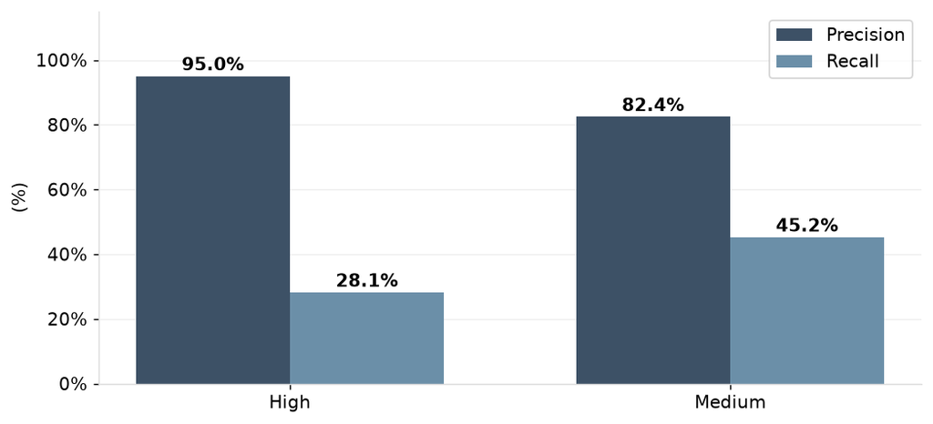

**How to read these numbers:** Precision answers "when the model raised a flag, how often was it right?" Recall answers "of all the jobs that actually failed, how many did the model catch?" High precision with lower recall means the model is conservative — it only flags jobs it is confident about, and misses some defective jobs that don't match the patterns it has learned. As more scoring periods accumulate, these metrics will be tracked over time to monitor whether model performance is stable or degrading.